# Experimental Design

Fall 2016

## Principles of experimental design

- **Replication**. It allows the experimenter to obtain an estimate of the experimental error
- **Randomization**. It requires the experimenter to use a random choice of every factor that is not of interest but might influence the outcome of the experiment. Such factors are called nuisance factors
- **Blocking**. Creating homogeneous blocks of data in which a nuisance factor is kept constant while the factor of interest is allowed to vary. Used to increase the accuracy with which the influence of the various factors is assessed in a given experiment
- **Block what you can, randomize what you cannot**

## Replicates

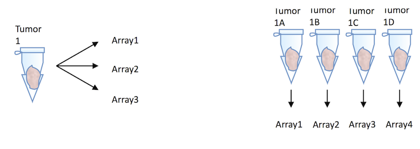

- **Technical** replicates and **Biological** replicates
- Rule of thumb: for two-fold change – use 3 replicates
- Smaller change – 5 replicates

## Randomization

- Each gene has multiple probes – randomize their position on the slide

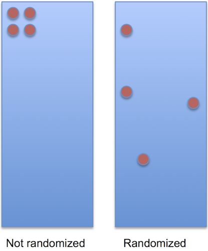

## Blocking

- Treatment and RNA extraction days are confounded

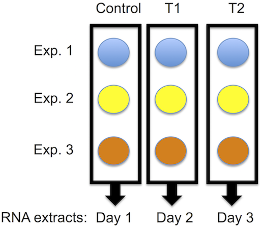

## Blocking

- Block replicated experiments

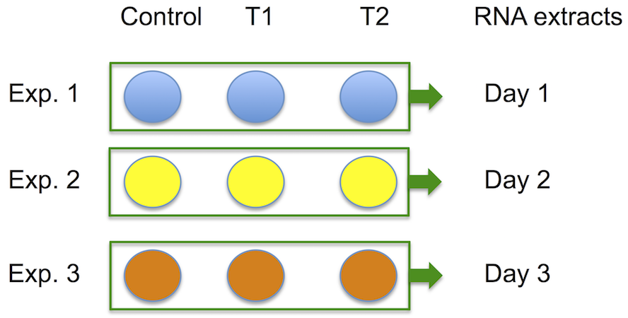

## Pooling

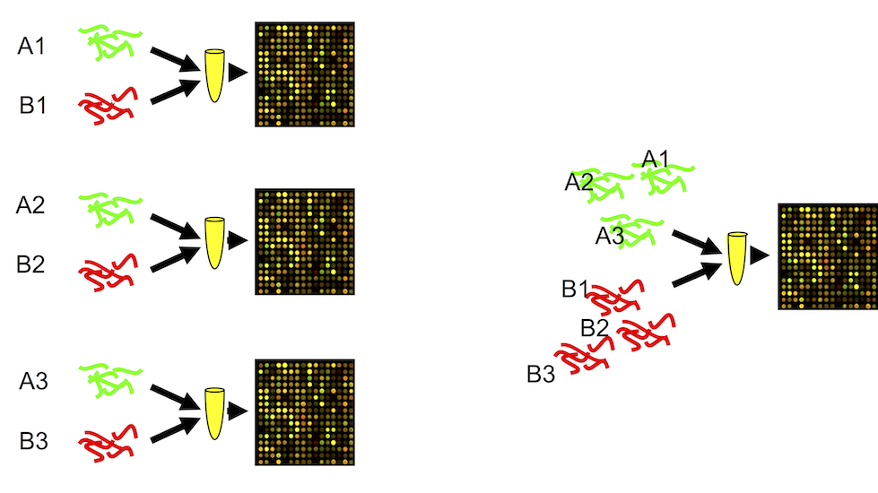

## Pooling

- OK when the interest is not on the individual, but on common patterns across individuals (population characteristics)
- Results in averaging -> reduces variability -> substantive features are easier to find
- Recommended when fewer than 3 arrays are used in each condition
- Beneficial when many subjects are pooled one pool vs independent samples in multiple pools

**"inference for most genes was not affected by pooling"**

C. Kendziorski, R. A. Irizarry, K.-S. Chen, J. D. Haag, and M. N. Gould. "On the utility of pooling biological samples in microarray experiments". PNAS March 2005, 102(12) 4252-4257

## How to allocate the samples to microarrays?

- which samples should be hybridized on the same slide?
- how different experimental designs affect outcome?
- what is the optimal design?

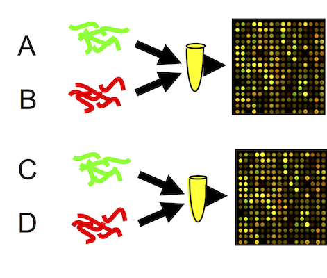

## Example of four-array experiment

### Dye swap

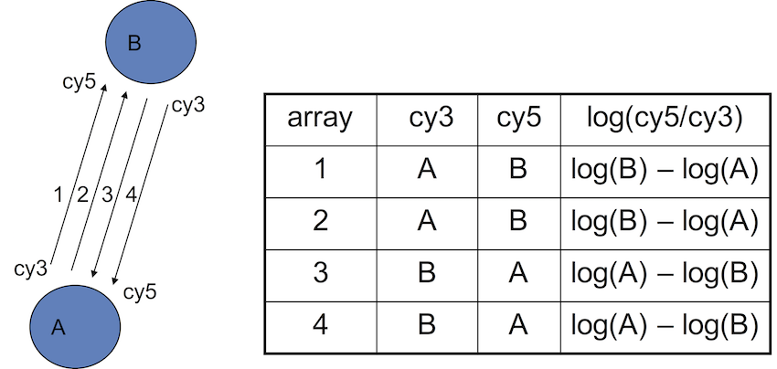

## Common reference design

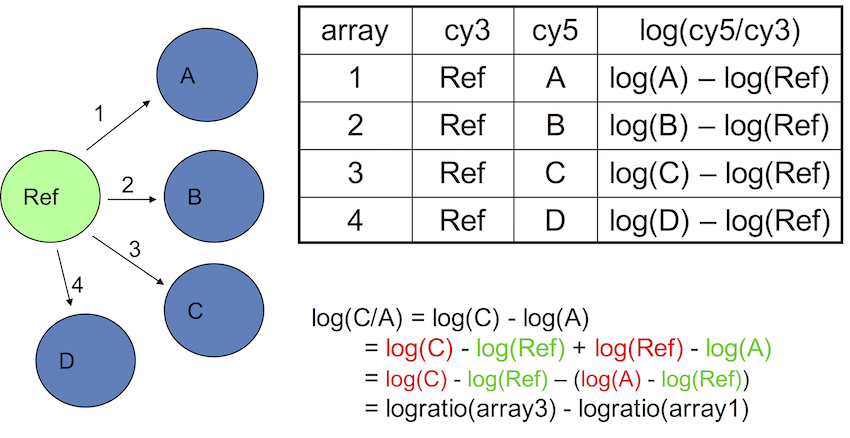

## Loop design

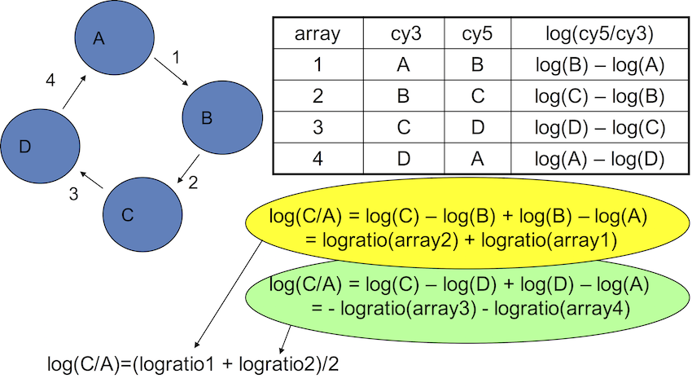

## Comparing the designs

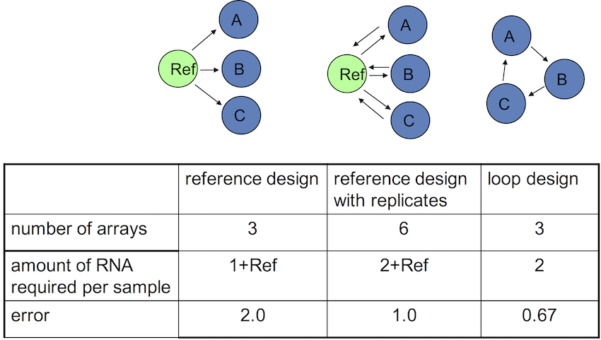

## Design with all direct pairwise comparisons

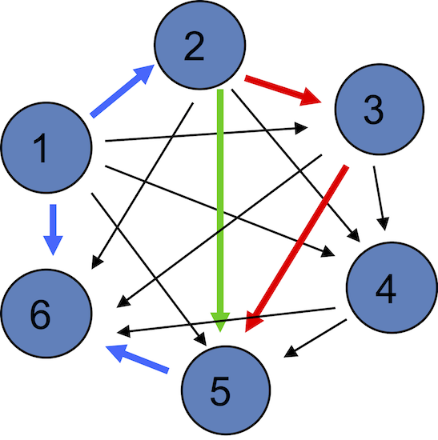